# Lab 02 - Take a sad plot and make it better

Group Members:Liuborui Shi, Thomas Horn, Solomon Zhang and Ruth Ashadu

2022-10-07

### Load packages and data

```r
library(tidyverse)
```

```r
staff <- read_csv("data/instructional-staff.csv")
```

Team member 1 should pull to download updates and begins here.

### Exercise 1

The data will have 55 rows.

Team member 1 should knit, stage & commit, and push all changes to GitHub.

Team member 2 should pull to download updates and begins here.

### Exercise 2

```r
staff <- read_csv("data/instructional-staff.csv")
staff_long <- staff %>%
  pivot_longer(
    cols = -faculty_type,
    names_to = "year",
    values_to = "percentage"
    )
```

### Exercise 3

```r
staff_long
```

```
## # A tibble: 55 × 3
##    faculty_type              year  percentage
##    <chr>                     <chr>      <dbl>
##  1 Full-Time Tenured Faculty 1975        29
##  2 Full-Time Tenured Faculty 1989        27.6
##  3 Full-Time Tenured Faculty 1993        25
##  4 Full-Time Tenured Faculty 1995        24.8
##  5 Full-Time Tenured Faculty 1999        21.8
##  6 Full-Time Tenured Faculty 2001        20.3
##  7 Full-Time Tenured Faculty 2003        19.3
##  8 Full-Time Tenured Faculty 2005        17.8
##  9 Full-Time Tenured Faculty 2007        17.2
## 10 Full-Time Tenured Faculty 2009        16.8
## # … with 45 more rows
```

Team member 2 should knit, stage & commit, and push all changes to GitHub.

Team member 3 should pull to download updates and begins here.

### Exercise 4

Nothing is shown on the graph.

```
## geom_path: Each group consists of only one observation. Do you need to adjust
## the group aesthetic?
```

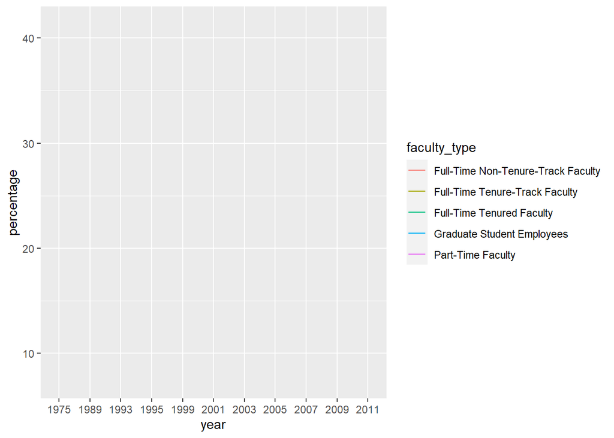

```r
staff_long %>%
  ggplot(aes(x = year, y = percentage, color = faculty_type)) +
  geom_line()
```